# Movie Buzz Breakdown🐝

Jennifer Warren

Presentation Date: 12/7/2021

## Summary of Data

I found this data online because I don’t have any of my own data. So as a preface: this whole script is just me playing around with R and R Markdown!

Since I had free range on this project, I thought it would be interesting to look at the relationship between how much money a movie makes in its first U.S. box office run, and several different factors such as if the movie is a:

- sequel
- action movie
- comedy movie
- animated movie
- horror movie

as well how what the film’s rating and budget were, how many views it received on http://traileraddict.com, number of message board comments on https://https://www.comingsoon.net/, and the percentage of votes on Fandango that “can’t wait to see” the film.

However, this script focuses on a just few of these data. These are the codes for each data type that are analyzed:

- BOX = Gross ($) from U.S. box office first run
- MPRATING = MPAA Rating code, where 1=G, 2=PG, 3=PG13, AND 4=R
- BUDGET = Production Budget in Millions ($)
- ADDICT = Number of Trailer Views on traileraddict.com
- CMNGSOON = Number of message board comments at comingsoon.net
- CNTWAIT3 = Percentage of Fandango votes that can’t wait to see the film

## Importing Data

```r
df_movies <- read_csv('C:/Users/091wa/Documents/5th year/EconS 523 (Data)/Final Presentation/movie_data.csv')

df <- df_movies %>%
  select(BOX, MPRATING, BUDGET, SEQUEL, ACTION, COMEDY, ANIMATED, HORROR, ADDICT, CMNGSOON, CNTWAIT3)
```

## Raw Data

This is what the data from the Excel file I used looks like:

```r
print(df)
```

```
## # A tibble: 62 x 11
##         BOX MPRATING BUDGET SEQUEL ACTION COMEDY ANIMATED HORROR ADDICT CMNGSOON
##       <dbl>    <dbl>  <dbl>  <dbl>  <dbl>  <dbl>    <dbl>  <dbl>  <dbl>    <dbl>
##  1 19167085        4   28        0      0      1        0      0  7860.       10
##  2 63106589        2  150        1      0      0        1      0  5737        59
##  3  5401605        4   37.4      0      0      1        0      0   850        24
##  4 67528882        3  200        1      1      0        0      0 15326        93
##  5 26223128        2  150        0      0      0        1      0  4574.       30
##  6 69637740        3   37        0      0      0        0      0 33324       533
##  7 14800723        3  130        0      0      0        0      0  3890.       20
##  8 31069826        3   80        0      0      1        0      0  2340.        6
##  9 12063452        3   40        1      1      0        0      0  3678        75
## 10  4271451        4   35        1      1      0        0      0  3586.      419
## # ... with 52 more rows, and 1 more variable: CNTWAIT3 <dbl>
```

## Shortened Data for Summary

I didn’t want to use that much information though, so I shortened it:

```r
df1 <- subset(df, select = -c(SEQUEL, ACTION, COMEDY, ANIMATED, HORROR))
print(df1)
```

```
## # A tibble: 62 x 6
##         BOX MPRATING BUDGET ADDICT CMNGSOON CNTWAIT3
##       <dbl>    <dbl>  <dbl>  <dbl>    <dbl>    <dbl>
##  1 19167085        4   28    7860.       10     0.49
##  2 63106589        2  150    5737        59     0.79
##  3  5401605        4   37.4   850        24     0.36
##  4 67528882        3  200   15326        93     0.76
##  5 26223128        2  150    4574.       30     0.53
##  6 69637740        3   37   33324       533     0.77
##  7 14800723        3  130    3890.       20     0.49
##  8 31069826        3   80    2340.        6     0.63
##  9 12063452        3   40    3678        75     0.59
## 10  4271451        4   35    3586.      419     0.62
## # ... with 52 more rows
```

Using the “subset” function, I created a new data frame with only the columns that I wanted to use later on. I used the “-c” to delete the data columns I didn’t want and left everything else alone.

## Summary Stats for Shortened Data

I didn’t really want to see an average for all the ones and zeros in the five columns that I deleted (whether the movie was action, comedy, animated, horror, or a sequel). This table is much shorter and easier to digest that it otherwise would have been!

```r
ss_movies <- sapply(df1,
                    function(i) c(mean(i), min(i), max(i), sd(i))) %>%
  data.frame() %>%
  round(digits = 2)

row.names(ss_movies) <- c('mean', 'min', 'max', 'sd')
ss_movies %>% kable(caption = 'Summary Statistics')
```

Summary Statistics

|  | BOX | MPRATING | BUDGET | ADDICT | CMNGSOON | CNTWAIT3 |
| --- | --- | --- | --- | --- | --- | --- |
| mean | 20720651 | 2.97 | 53.29 | 5933.81 | 78.21 | 0.48 |
| min | 511920 | 1.00 | 5.00 | 568.00 | 2.00 | 0.15 |
| max | 70950500 | 4.00 | 200.00 | 45865.69 | 594.00 | 0.79 |
| sd | 17492443 | 0.81 | 42.87 | 7674.61 | 124.55 | 0.16 |

## Correlation between Budget and Box Office $$

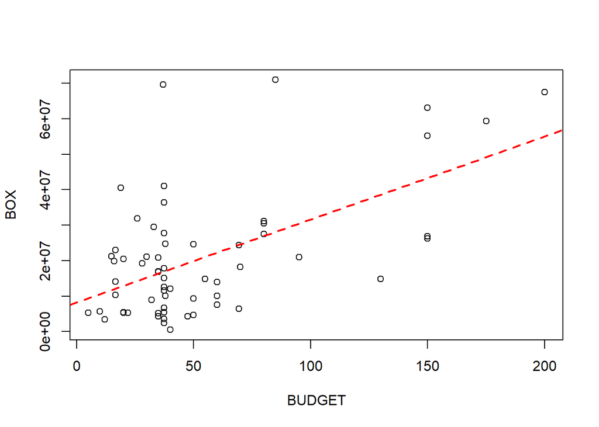

```r
attach(df)
movies <- lm(BOX~BUDGET)
plot(BUDGET,BOX)
abline(coefficients(movies), lwd=2, lty=2, col='red')
```

**Wow! Imagine that! Movies that have higher budgets make more money! The theory has been confirmed.**

And who doesn’t love a good summary stats table? Here it is:

```r
summary(movies)
```

```
##
## Call:
## lm(formula = BOX ~ BUDGET)
##
## Residuals:
##       Min        1Q    Median        3Q       Max
## -23844872 -10060273  -3032775   7565032  52722776
##
## Coefficients:
##             Estimate Std. Error t value Pr(>|t|)
## (Intercept)  8269445    2944005   2.809   0.0067 **
## BUDGET        233663      43183   5.411 1.15e-06 ***
## ---
## Signif. codes:  0 '***' 0.001 '**' 0.01 '*' 0.05 '.' 0.1 ' ' 1
##
## Residual standard error: 14460000 on 60 degrees of freedom
## Multiple R-squared:  0.3279, Adjusted R-squared:  0.3167
## F-statistic: 29.28 on 1 and 60 DF,  p-value: 1.153e-06
```

**We can see that a movie’s budget is not the main reason for its box office revenue, but it can take some credit for why a movie makes the money it does.**

## Correlation between Trailer Views and Box Office $$

Now let’s look at how the amount of views a movie trailer recieved corresponds to how much money it made:

```r
attach(df)
```

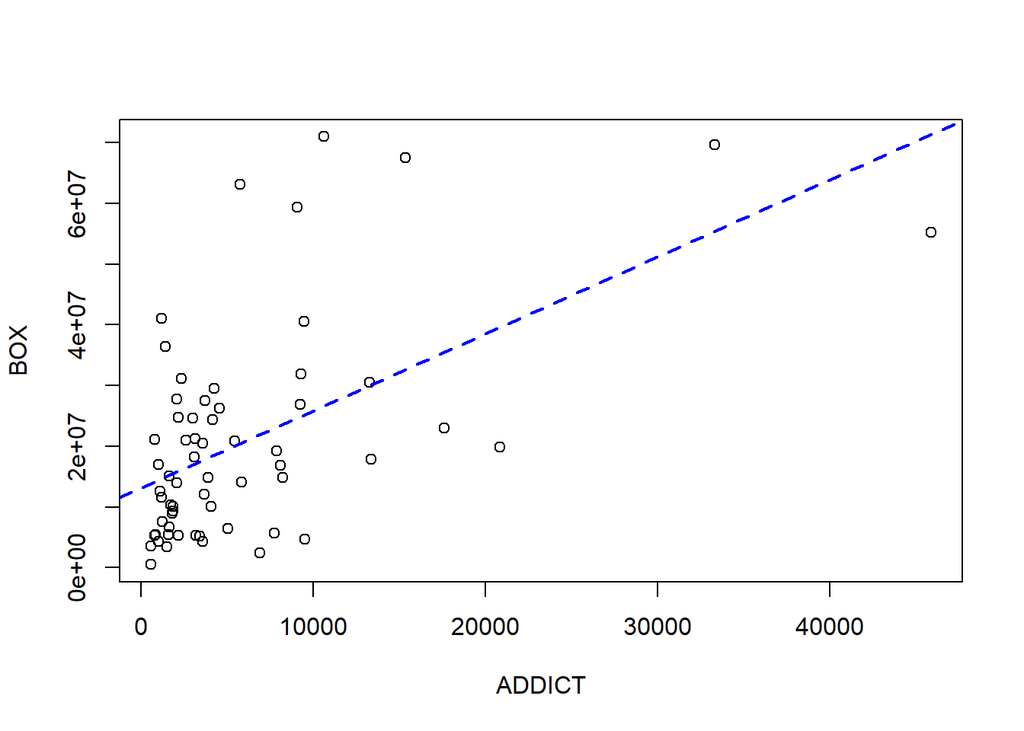

```r
movies2 <- lm(BOX~ADDICT)
plot(ADDICT,BOX)
abline(coefficients(movies2), lwd=2, lty=2, col='blue')
```

This involves the same steps as the last graph, I just wanted to switch up one of the variables.

## Correlation between % Who “Can’t Wait to See” and Box Office $$

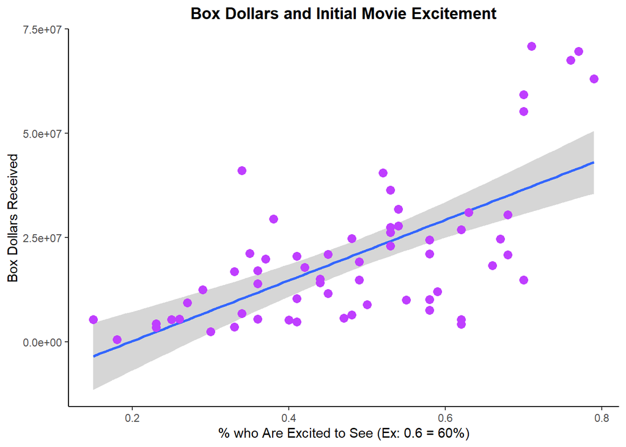

```r
ggplot(df, aes(CNTWAIT3, BOX)) +
  theme_classic() +
  geom_smooth(method = 'lm') +
  geom_point(color = 'darkorchid1', size = 3) +
  labs(title = 'Box Dollars and Initial Movie Excitement',
       x = '% who Are Excited to See (Ex: 0.6 = 60%)',
       y = 'Box Dollars Received') +
  theme(plot.title = element_text(face = 'bold', hjust = 0.5))
```

## That’s all Folks!

[figure not shown]

[output not shown]